# Individual Fitted Distributions

24 November 2022, 23:48

### Elicited judgements

| quantiles | A | B | C |
| --- | --- | --- | --- |
| 0.25 | 25 | 10 | 70 |
| 0.50 | 50 | 30 | 90 |
| 0.75 | 75 | 50 | 99 |

### Distributions

All parameter values reported to 3 significant figures.

#### Normal

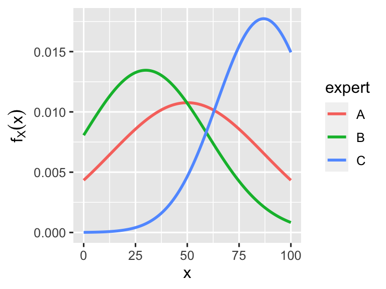

$$f_X(x) = \frac{1}{\sqrt{2\pi\sigma^2}}
\exp\left(-\frac{1}{2 \sigma^2}(x - \mu)^2\right),\quad
-\infty<x<\infty,$$
with

|  | $\mu$ | $\sigma^2$ |
| --- | --- | --- |
| A | 50.0 | 1370 |
| B | 30.0 | 879 |
| C | 86.8 | 506 |

Sample `n = 1000` random values (for expert A) with the command

`rnorm(n = 1000, mean = 50, sd = sqrt(1370))`

#### Student$-t$

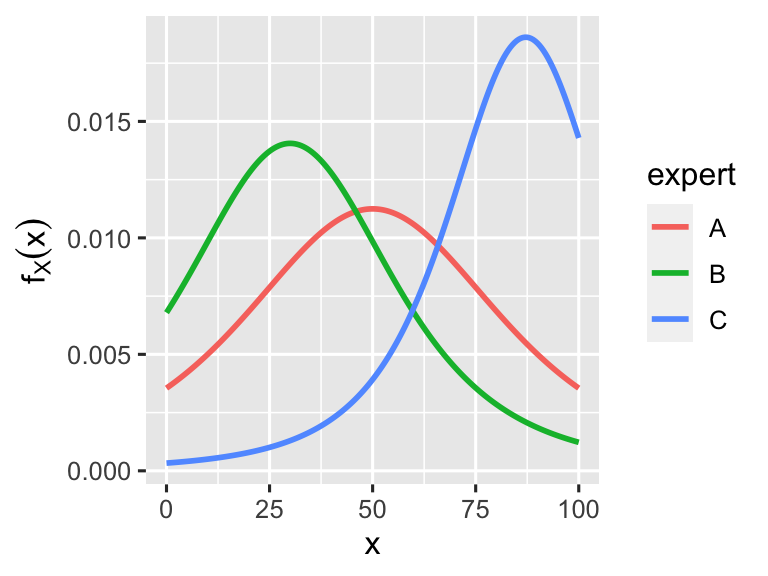

$$f_X(x) = \frac{\Gamma((\nu + 1)/2)}{\Gamma(\nu/2)\sigma\sqrt{\nu \pi}}
\left(1 + \frac{1}{\nu}\left(\frac{x -
\mu}{\sigma}\right)^2\right)^{-(\nu + 1)/2},\quad
-\infty<x<\infty,$$
with

|  | $\mu$ | $\sigma$ | $\nu$ |
| --- | --- | --- | --- |
| A | 50.0 | 32.7 | 3 |
| B | 30.0 | 26.1 | 3 |
| C | 87.1 | 19.7 | 3 |

Sample `n = 1000` random values (for expert A) with the command

`50 + 32.7 * rt(n = 1000, df = 3)`

#### Log normal

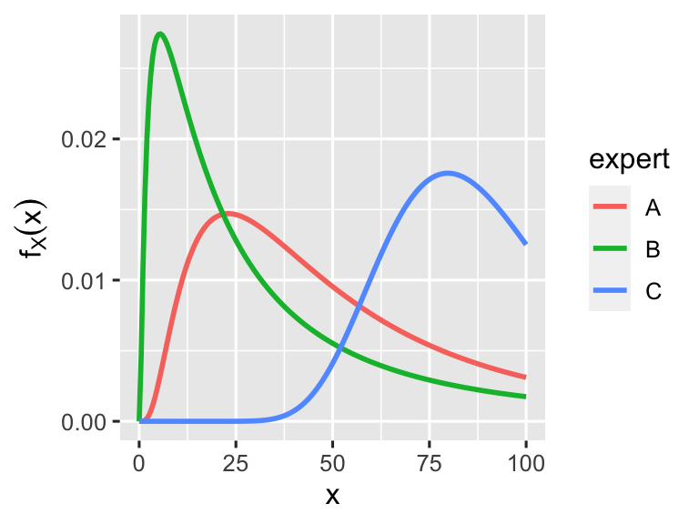

$$f_X(x) = \frac{1}{x-L} \times
\frac{1}{\sqrt{2\pi\sigma^2}}
\exp\left(-\frac{1}{2\sigma^2}(\ln (x-L) - \mu)^2\right), \quad x
>L,$$

and $f_X(x)=0$ otherwise, with

|  | $\mu$ | $\sigma^2$ | $L$ |
| --- | --- | --- | --- |
| A | 3.83 | 0.6920 | 0 |
| B | 3.23 | 1.5500 | 0 |
| C | 4.45 | 0.0751 | 0 |

Sample `n = 1000` random values (for expert A) with the command

`0 + rlnorm(n = 1000, meanlog = 3.83, sdlog = 0.832)`

#### Gamma

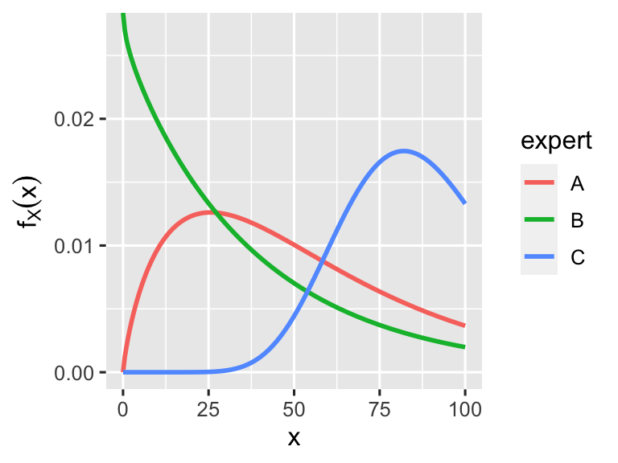

$$f_X(x) =\frac{\beta ^
{\alpha}}{\Gamma(\alpha)}(x-L)^{\alpha - 1} \exp\left(- \beta
(x-L)\right), \quad x >L,$$
and $f_X(x)=0$ otherwise, with

|  | $\alpha$ | $\beta$ | $L$ |
| --- | --- | --- | --- |
| A | 1.800 | 0.0313 | 0 |
| B | 0.976 | 0.0250 | 0 |
| C | 14.100 | 0.1590 | 0 |

Sample `n = 1000` random values (for expert A) with the command

`0 + rgamma(n = 1000, shape = 1.8, rate = 0.0313)`

#### Log Student$-t$

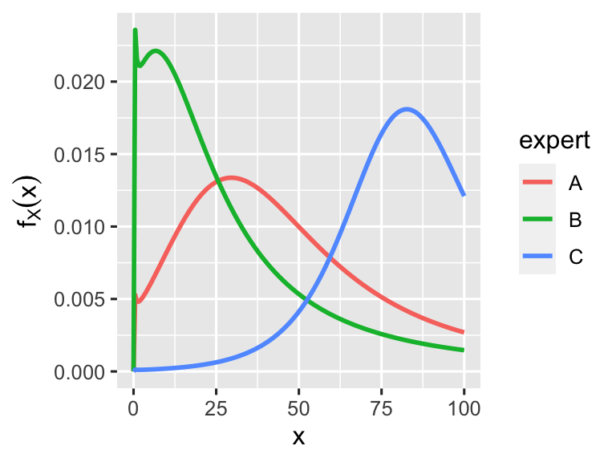

$$f_X(x) =\frac{1}{x-L} \times
\frac{\Gamma((\nu + 1)/2)}{\Gamma(\nu/2)\times\sigma\times \sqrt{\nu
\pi}} \left(1 + \frac{1}{\nu}\left(\frac{\ln (x-L) -
\mu}{\sigma}\right)^2\right)^{-(\nu + 1)/2}, \quad x >L,$$
and $f_X(x)=0$ otherwise, with

|  | $\mu$ | $\sigma$ | $\nu$ | $L$ |
| --- | --- | --- | --- | --- |
| A | 3.84 | 0.732 | 3 | 0 |
| B | 3.25 | 1.090 | 3 | 0 |
| C | 4.46 | 0.240 | 3 | 0 |

Sample `n = 1000` random values (for expert A) with the command

`0 + exp( 3.84 + 0.732 * rt(n = 1000, df = 3))`

#### Beta

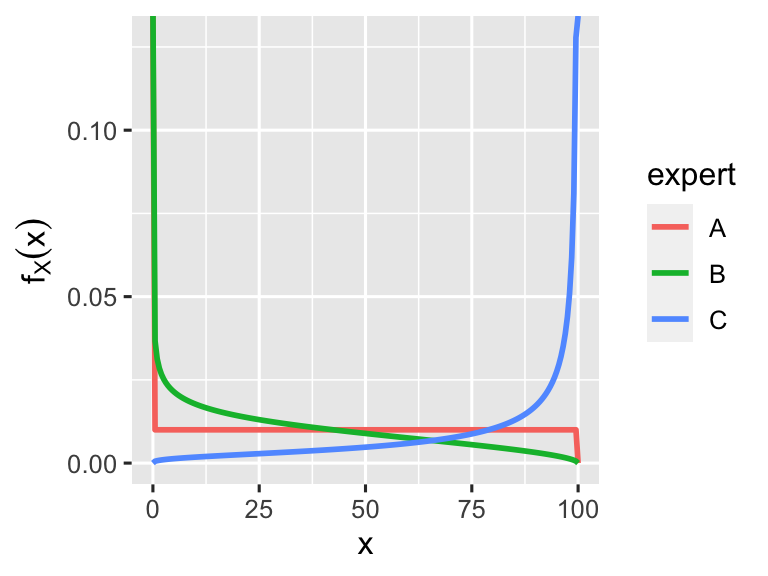

$$f_X(x) =
\frac{1}{U-L}\times\frac{\Gamma(\alpha +
\beta)}{\Gamma(\alpha)\Gamma(\beta)} \left(\frac{x-L}{U-L}\right)
^{\alpha - 1} \left(1 - \left(\frac{x-L}{U-L}\right)\right)^{\beta - 1},
\quad L < x <U,$$
and $f_X(x) = 0$ otherwise, with

|  | $\alpha$ | $\beta$ | $L$ | $U$ |
| --- | --- | --- | --- | --- |
| A | 1.000 | 1.000 | 0 | 100 |
| B | 0.775 | 1.560 | 0 | 100 |
| C | 1.370 | 0.341 | 0 | 100 |

Sample `n = 1000` random values (for expert A) with the command

`0 + (100) * rbeta(n = 1000, shape1 = 1, shape2 = 1)`

#### Mirror log normal

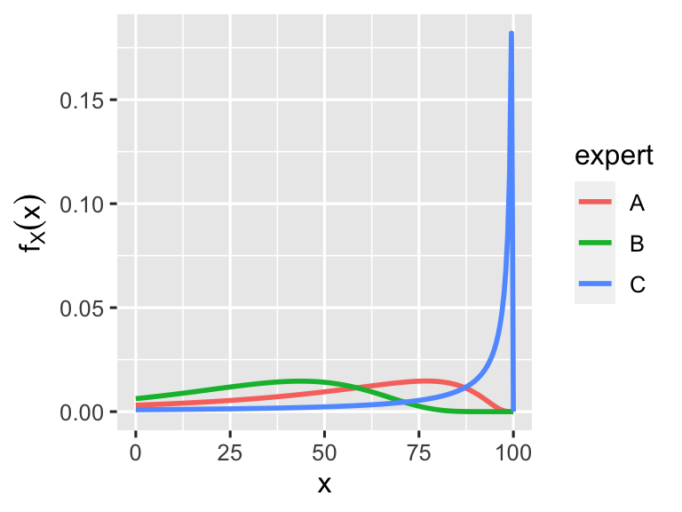

$$f_X(x) = \frac{1}{U-x} \times
\frac{1}{\sqrt{2\pi\sigma^2}}
\exp\left(-\frac{1}{2\sigma^2}(\ln (U-x) - \mu)^2\right), \quad x
<U,$$

and $f_X(x)=0$ otherwise, with

|  | $\mu$ | $\sigma^2$ | $U$ |
| --- | --- | --- | --- |
| A | 3.83 | 0.692 | 100 |
| B | 4.22 | 0.192 | 100 |
| C | 1.96 | 6.880 | 100 |

Sample `n = 1000` random values (for expert A) with the command

`100 - rlnorm(n = 1000, meanlog = 3.83, sdlog = 0.832)`

#### Mirror gamma

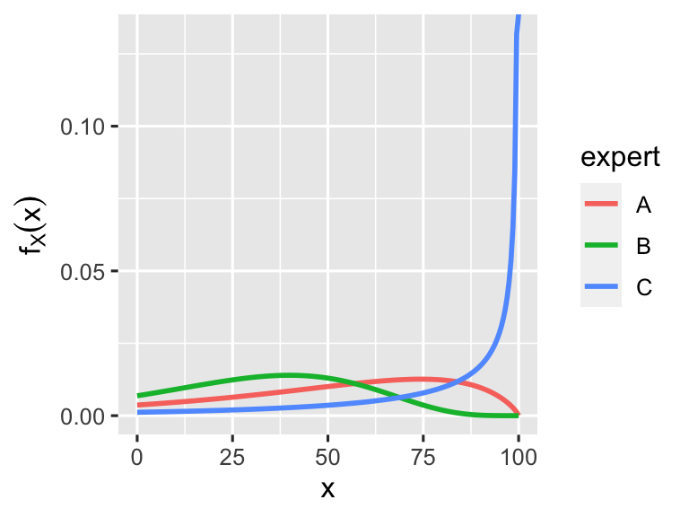

$$f_X(x) =\frac{\beta ^
{\alpha}}{\Gamma(\alpha)}(U-x)^{\alpha - 1} \exp\left(- \beta
(U-x)\right), \quad x <U,$$
and $f_X(x)=0$ otherwise, with

|  | $\alpha$ | $\beta$ | $U$ |
| --- | --- | --- | --- |
| A | 1.800 | 0.0313 | 100 |
| B | 5.580 | 0.0762 | 100 |
| C | 0.364 | 0.0137 | 100 |

Sample `n = 1000` random values (for expert A) with the command

`100 - rgamma(n = 1000, shape = 1.8, rate = 0.0313)`

#### Mirror log Student$-t$

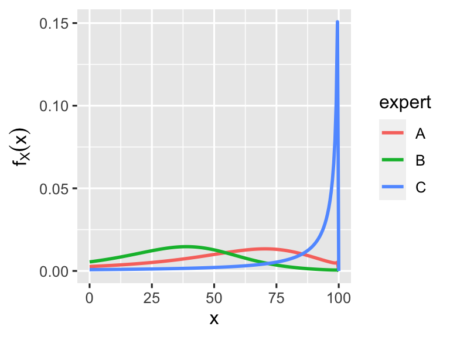

$$f_X(x) =\frac{1}{U-x} \times
\frac{\Gamma((\nu + 1)/2)}{\Gamma(\nu/2)\times\sigma\times \sqrt{\nu
\pi}} \left(1 + \frac{1}{\nu}\left(\frac{\ln (U-x) -
\mu}{\sigma}\right)^2\right)^{-(\nu + 1)/2}, \quad x <U,$$
and $f_X(x)=0$ otherwise, with

|  | $\mu$ | $\sigma$ | $\nu$ | $U$ |
| --- | --- | --- | --- | --- |
| A | 3.84 | 0.732 | 3 | 100 |
| B | 4.23 | 0.386 | 3 | 100 |
| C | 1.99 | 2.300 | 3 | 100 |

Sample `n = 1000` random values (for expert A) with the command

`100 - exp( 3.84 + 0.732 * rt(n = 1000, df = 3))`